# Landskapsanalys v2.1: Faktorantalskanslighet

> Denna rapport dokumenterar faktorantalskansligheten ovanpa `landskapsanalys_v2_1_geomweight58_res9`, med `varimax` som arbetsdefault och faktorantal `4, 5, 6, 7, 8`.

## 1. Syfte

Denna rapport svarar pa fragan:

**Ar fem faktorer fortfarande rimligt i `v2.1`, eller bor modellen egentligen forenkla till fyra eller expandera till sex-plus?**

Testet bygger pa samma `v2.1`-kontextmatris som tidigare, men med ett fast metodpaket:

- rotation = varimax
- factor counts = `4, 5, 6, 7, 8`
- klusterprovning = `K = 5..10`

## 2. Testdesign

Analysen bygger pa 7286 hexagoner och 570 rensade kontextkolumner, direkt lasna fran landskapsanalys_v2_1_geomweight58_res9.

| Komponent | Val |
| --- | --- |
| Kallmodell | landskapsanalys_v2_1_geomweight58_res9 |
| Rotation | varimax |
| Faktorantal | 4, 5, 6, 7, 8 |
| Jamforda K | 5..10 |
| Fokus-K | 5 och 6 |
| Klusteralgoritm | kmeans (Lloyd, nstart = 50, iter.max = 500) |

## 3. Huvudresultat

Fyra faktorer ger hogst klusterseparation (silhouette 0.379), men fem faktorer ar fortfarande den starkaste kompromissen mellan tolkbarhet, klusterbalans och uppdelning av kust/geologi.

| Faktorer | Kumulativ varians | TLI | RMSEA | Bast K | Bast silhouette | Storsta klustershare | Minsta klustershare |
| --- | --- | --- | --- | --- | --- | --- | --- |
| 4 | 32.07% | 0.765 | 0.131 | 5 | 0.379 | 53.5% | 4.2% |
| 5 | 36.02% | 0.808 | 0.118 | 6 | 0.311 | 50.7% | 2.9% |
| 6 | 39.49% | 0.842 | 0.107 | 6 | 0.284 | 56.3% | 3.4% |
| 7 | 42.10% | 0.861 | 0.101 | 6 | 0.280 | 58.9% | 1.9% |
| 8 | 44.34% | 0.875 | 0.096 | 6 | 0.254 | 55.5% | 2.2% |

Det finns en tydlig trade-off:

- fler faktorer ger battre FA-fit
- farre faktorer ger battre klusterseparation
- fem faktorer ligger mitt i denna brytpunkt

## 4. Fit For Faktoranalysen

### 4.1 Forklarad varians

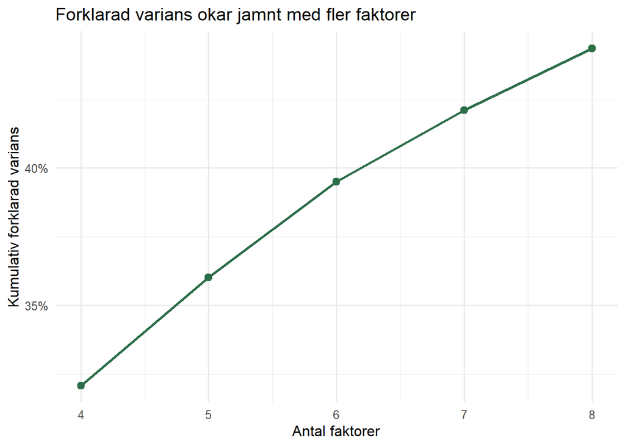

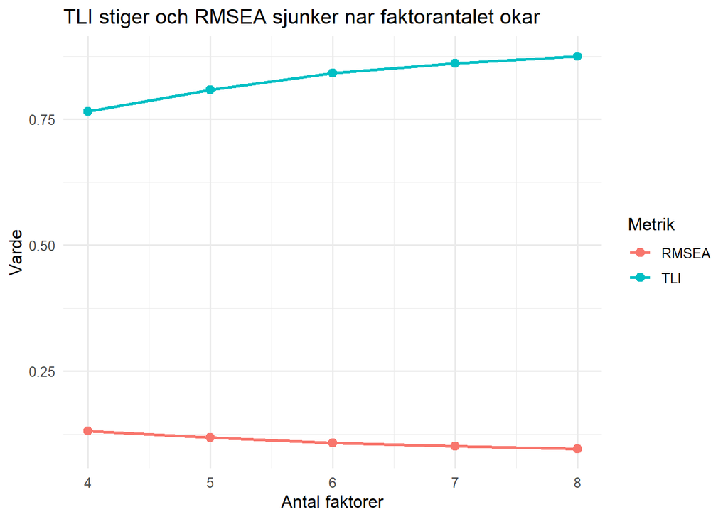

FA-fit blir tydligt battre nar modellen gar fran `4` till `8` faktorer:

- TLI: `0.765 -> 0.875`
- RMSEA: `0.131 -> 0.096`

Det betyder dock inte automatiskt att `8` faktorer ar bast. En del av vinsten ar bara att modellen blir friare och mer detaljerad.

## 5. Klusterbeteende

### 5.1 Basta K per faktorantal

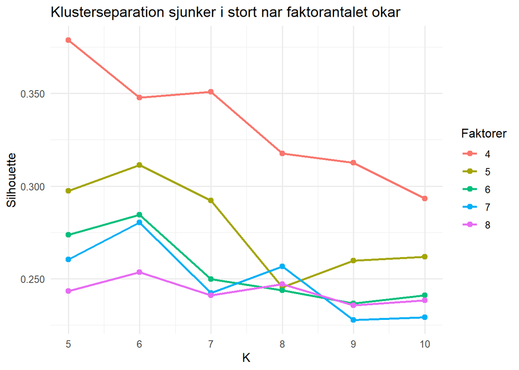

Silhouette-bilden ar ganska klar:

- `4` faktorer ger hogst silhouette och foredrar `K = 5`
- `5` faktorer flyttar bast K till `6`
- `6-8` faktorer behaller `K = 6`, men silhouette fortsatter nedat

### 5.2 Fokus pa K = 5 och K = 6

| Faktorer | K | Storsta klustershare | Minsta klustershare | Silhouette |
| --- | --- | --- | --- | --- |
| 4 | 5 | 53.5% | 4.2% | 0.379 |
| 4 | 6 | 48.5% | 3.8% | 0.348 |
| 5 | 5 | 56.6% | 4.6% | 0.297 |
| 5 | 6 | 50.7% | 2.9% | 0.311 |
| 6 | 5 | 57.3% | 6.7% | 0.274 |
| 6 | 6 | 56.3% | 3.4% | 0.284 |
| 7 | 5 | 57.2% | 2.7% | 0.260 |
| 7 | 6 | 58.9% | 1.9% | 0.280 |
| 8 | 5 | 58.9% | 8.2% | 0.243 |
| 8 | 6 | 55.5% | 2.2% | 0.254 |

Fyra faktorer ar starka for klustring, men de ar ocksa grova:

- `4 faktorer, K=5` har silhouette `0.379`
- `5 faktorer, K=6` har silhouette `0.311`
- `6+ faktorer` ger gradvis svagare klusterseparation och ofta mer dominerande storsta kluster

## 6. Stabilitet Mellan Narliggande Faktorantal

| K | Vanster faktorantal | Hoger faktorantal | ARI |
| --- | --- | --- | --- |
| 5 | 4 | 5 | 0.655 |
| 5 | 5 | 6 | 0.432 |
| 5 | 6 | 7 | 0.702 |
| 5 | 7 | 8 | 0.764 |
| 6 | 4 | 5 | 0.677 |
| 6 | 5 | 6 | 0.497 |
| 6 | 6 | 7 | 0.736 |
| 6 | 7 | 8 | 0.823 |

Det viktigaste brottet ligger mellan `5` och `6` faktorer:

- `K = 5`: ARI `0.432`
- `K = 6`: ARI `0.497`

Det betyder att overgangen fran `5` till `6` inte bara ar en liten finjustering. Det ar en faktisk omstrukturering av klusterrummet.

## 7. Vad Hander Innehallsligt?

| Faktorer totalt | Faktor | Variabel | Laddning |
| --- | --- | --- | --- |
| 4 | F1 | mean_gc_fastboende_count_k250 | 0.923 |
| 4 | F1 | std_gc_fastboende_count_k250 | 0.917 |
| 4 | F1 | mean_gc_fastboende_count_k1000 | 0.915 |
| 4 | F1 | mean_gc_built_low_selection_share_k1000 | 0.903 |
| 4 | F1 | mean_gc_buildings_low_share_k1000 | 0.886 |
| 4 | F2 | mean_gc_jordart_es_flyvesand_share_k1000 | 0.851 |
| 4 | F2 | mean_gc_jordart_es_flyvesand_share_k250 | 0.841 |
| 4 | F2 | std_gc_jordart_es_flyvesand_share_k1000 | 0.839 |
| 4 | F2 | mean_gc_jordart_es_flyvesand_share_k100 | 0.819 |
| 4 | F2 | std_gc_jordart_es_flyvesand_share_k250 | 0.815 |
| 4 | F3 | mean_gc_forest_share_k1000 | 0.869 |
| 4 | F3 | mean_gc_forest_share_k250 | 0.865 |
| 4 | F3 | mean_gc_fredskov_share_k1000 | 0.853 |
| 4 | F3 | mean_gc_natura_habitat_areas_share_k250 | 0.848 |
| 4 | F3 | mean_gc_natura_habitat_areas_share_k100 | 0.839 |
| 4 | F4 | mean_gc_relief_m_k1000 | 0.845 |
| 4 | F4 | mean_gc_relief_m_k250 | 0.836 |
| 4 | F4 | mean_gc_relief_m_k100 | 0.810 |
| 4 | F4 | mean_gc_jordart_pkv_prekvartart_lag_share_k1000 | 0.787 |
| 4 | F4 | mean_gc_relief_m_k50 | 0.781 |
| 5 | F1 | mean_gc_jordart_es_flyvesand_share_k1000 | 0.843 |
| 5 | F1 | mean_gc_jordart_es_flyvesand_share_k250 | 0.840 |
| 5 | F1 | std_gc_jordart_es_flyvesand_share_k1000 | 0.835 |
| 5 | F1 | mean_gc_jordart_es_flyvesand_share_k100 | 0.818 |
| 5 | F1 | std_gc_jordart_es_flyvesand_share_k250 | 0.817 |
| 5 | F2 | mean_gc_fastboende_count_k250 | 0.929 |
| 5 | F2 | std_gc_fastboende_count_k250 | 0.922 |
| 5 | F2 | mean_gc_fastboende_count_k1000 | 0.903 |
| 5 | F2 | mean_gc_built_low_selection_share_k1000 | 0.897 |
| 5 | F2 | std_gc_fastboende_count_k100 | 0.887 |
| 5 | F3 | mean_gc_forest_share_k1000 | 0.872 |
| 5 | F3 | mean_gc_forest_share_k250 | 0.867 |
| 5 | F3 | mean_gc_fredskov_share_k1000 | 0.857 |
| 5 | F3 | mean_gc_natura_habitat_areas_share_k250 | 0.849 |
| 5 | F3 | mean_gc_fredskov_share_k250 | 0.842 |
| 5 | F4 | mean_gc_relief_m_k1000 | 0.864 |
| 5 | F4 | mean_gc_relief_m_k250 | 0.852 |
| 5 | F4 | mean_gc_relief_m_k100 | 0.824 |
| 5 | F4 | mean_gc_relief_m_k50 | 0.793 |
| 5 | F4 | mean_gc_jordart_pkv_prekvartart_lag_share_k1000 | 0.787 |
| 5 | F5 | mean_gc_jordart_marina_sand_och_grus_ovrigt_share_k1000 | 0.648 |
| 5 | F5 | mean_gc_jordart_marina_sand_och_grus_ovrigt_share_k250 | 0.631 |
| 5 | F5 | mean_gc_jordart_marina_sand_och_grus_ovrigt_share_k100 | 0.599 |
| 5 | F5 | std_gc_jordart_marina_sand_och_grus_ovrigt_share_k1000 | 0.589 |
| 5 | F5 | std_gc_jordart_marina_sand_och_grus_ovrigt_share_k250 | 0.586 |
| 6 | F1 | mean_gc_forest_share_k1000 | 0.880 |
| 6 | F1 | mean_gc_forest_share_k250 | 0.869 |
| 6 | F1 | mean_gc_fredskov_share_k1000 | 0.868 |
| 6 | F1 | mean_gc_natura_habitat_areas_share_k250 | 0.854 |
| 6 | F1 | mean_gc_fredskov_share_k250 | 0.849 |
| 6 | F2 | mean_gc_fastboende_count_k250 | 0.944 |
| 6 | F2 | std_gc_fastboende_count_k250 | 0.913 |
| 6 | F2 | mean_gc_fastboende_count_k1000 | 0.907 |
| 6 | F2 | std_gc_fastboende_count_k100 | 0.883 |
| 6 | F2 | mean_gc_built_centre_share_k1000 | 0.868 |
| 6 | F3 | mean_gc_jordart_es_flyvesand_share_k250 | 0.864 |
| 6 | F3 | mean_gc_jordart_es_flyvesand_share_k1000 | 0.854 |
| 6 | F3 | mean_gc_jordart_es_flyvesand_share_k100 | 0.843 |
| 6 | F3 | mean_gc_jordart_es_flyvesand_share_k50 | 0.821 |
| 6 | F3 | std_gc_sand_dune_share_k250 | 0.816 |
| 6 | F4 | mean_gc_relief_m_k1000 | 0.813 |
| 6 | F4 | mean_gc_relief_m_k250 | 0.809 |
| 6 | F4 | mean_gc_relief_m_k100 | 0.786 |
| 6 | F4 | std_gc_jordart_pkv_prekvartart_lag_share_k1000 | 0.773 |
| 6 | F4 | mean_gc_jordart_pkv_prekvartart_lag_share_k1000 | 0.773 |
| 6 | F5 | std_gc_prekvart_sedimentara_formationer_ovrigt_share_k1000 | 0.763 |
| 6 | F5 | mean_gc_prekvart_sedimentara_formationer_ovrigt_share_k1000 | 0.757 |
| 6 | F5 | std_gc_prekvart_sedimentara_formationer_ovrigt_share_k250 | 0.667 |
| 6 | F5 | mean_gc_aviation_bird_collision_share_k1000 | 0.650 |
| 6 | F5 | mean_gc_aviation_bird_collision_share_k250 | 0.646 |
| 6 | F6 | mean_gc_jordart_marina_sand_och_grus_ovrigt_share_k250 | 0.708 |
| 6 | F6 | mean_gc_jordart_marina_sand_och_grus_ovrigt_share_k1000 | 0.693 |
| 6 | F6 | mean_gc_jordart_marina_sand_och_grus_ovrigt_share_k100 | 0.680 |
| 6 | F6 | mean_gc_jordart_marina_sand_och_grus_ovrigt_share_k50 | 0.647 |
| 6 | F6 | std_gc_jordart_marina_sand_och_grus_ovrigt_share_k100 | 0.605 |

Det mest metodiskt intressanta ar detta:

- `4` faktorer ser ut att sla ihop det som i `5` faktorer blir en separat marin/sandig kustfaktor
- `5` faktorer ger fortfarande en tydlig extra kust-geologisk gradient utan att modellen spricker upp for mycket
- `6` faktorer introducerar en smalare faktor som delvis ser ut att blandas av specifika geologiska formationer och `aviation_bird_collision`

Just den sista punkten gor `6` faktorer mindre attraktivt som arbetsdefault just nu. Det ser mer ut som en metodisk uppsplittring av specialsignaler an som en tydligare overgripande landskapslogik.

## 8. Egenvardesbilden

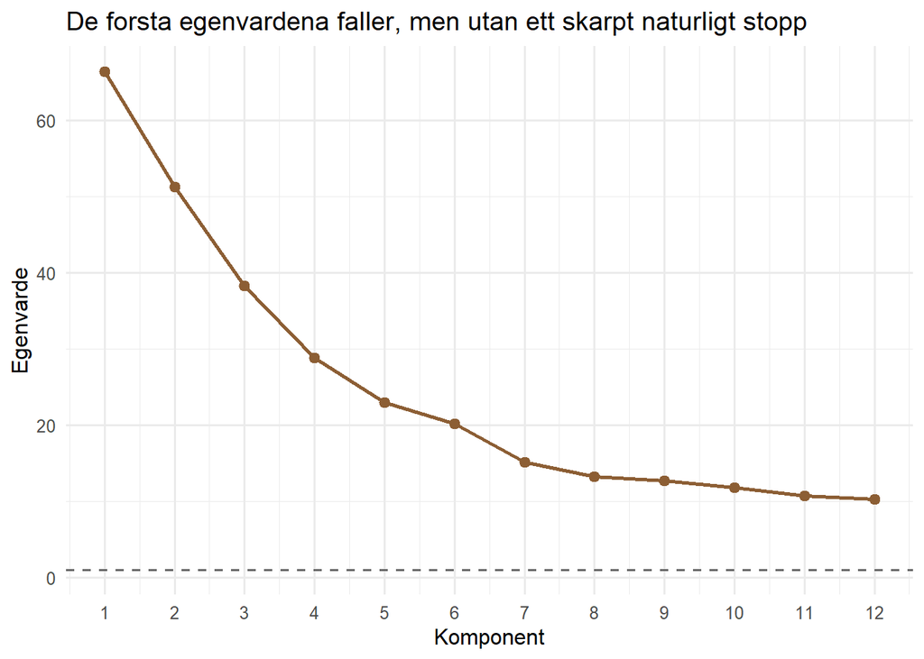

Egenvardena visar inget rent och enkelt stopp vid `5`. Det ar inte overraskande, eftersom matrisen innehaller manga nara beslektade variabler over flera skalor.

Med andra ord:

- egenvardena alene legitimerar inte `5`
- men de legitimerar inte heller ett enkelt hopp till `8`

## 9. Arbetsposition

Min arbetsposition efter denna kanslighetsrunda ar:

1. Behall `5` faktorer som arbetsdefault i `v2.1`.
2. Tolka `4` faktorer som en viktig kontroll: modellen kan bli mer klusterbar om vi tillater mer sammanslagning.
3. Tolka `6` faktorer som en verklig alternativ modell, men inte som basta arbetsval just nu.
4. Tolka `7-8` faktorer som overdetaljerade for den aktuella rapportnivan.
5. Anvand resultatet som argument for att ga vidare till leave-one-theme-out innan vi overger femfaktorslosningen.

Det viktigaste metodbeslutet just nu ar alltsa:

**Behall `v2.1` med `varimax`, `5` faktorer och `K = 6` som arbetsmodell for fortsatt granskning.**